# STAT 5702 Final Project - NYC Rodent Inspection

Lizhou He, Mingfeng Li, Nan You, Hantang Zhou

## Part 1. Introduction

We chose to investigate in the NYC Rodent Inspection data, which we found on NYC Open Data (https://data.cityofnewyork.us/Health/Rodent-Inspection/p937-wjvj). Since the rat distribution and population are related to public health and housing conditions, it is helpful to learn about information of rat inspection, like the active rates over years in different regions and the inspection results. And we developed a web-application NYC Rodent Inspection Map (http://104.196.205.14:8111/) to help visualize the data in both time and space dimensions, which can provide significant information for choosing a living place, controlling the spread of infectious diseases and etc.

Our team is composed of four members: Lizhou He, Mingfeng Li, Nan You, and Hantang Zhou. We keep our work on GitHub: https://github.com/htmajorcn/edav_project. For this project, we roughly divided our work as followed:

Lizhou He (lh2922): analyzed the data of time series, developed the web application and wrote part of the analysis

Mingfeng Li (ml4209): analyzed the spatial variables, wrote part of the analysis, attempted to use GeoJson (not included), organized the project tasks and managed the Rmd file

Nan You (ny2286): analyzed the result variable, integrated and supplemented to team members’ data analyses, wrote multiple parts of the report, and coordinated members’ job

Hantang Zhou (hz2562): cleaned the data, finished the coding phase of the interactive part, and wrote part of the analysis

$~$

## Part 2. Description of data

`inspection_type`: different types of rat inspection, including 1) Initial Inspection (Inspection conducted in response to a complaint, or a proactive inspection conducted through our neighborhood indexing program), 2) Compliance Inspection (If a property fails its initial inspection, the Health Department will conduct a follow up inspection), 3) Baiting (Application of rodenticide, or monitoring visit by a Health Department Pest Control Professional), and 4) Clean Up (The removal of garbage and clutter from a property by the Health Department).

`borough`: names of NYC boroughs.

`zip_code`: postal zip code.

`latitude`: Latitude in decimal degrees of the inspected taxlot.

`longitude`: Longitude in decimal degrees of the inspected taxlot.

`inspection_date`: Date of the inspection.

`result`: Result of the inspection, including 1) Active Rat Signs (ARS) - ARS include any of six different signs: fresh tracks, fresh droppings, active burrows, active runways and rub marks, fresh gnawing marks, and live rats, 2) Bait applied, 3) Cleanup done, 4) Monitoring visit, 5) Passed Inspection, and 6)Problem Conditions.

We temporarily dropped the other uninterested columns. Additionally, due to the extremely large amount of data, we also dropped the rows that contain NA(s).

One limit of this data set is that we noticed that the rates of inspection do not necessarily reflect the population of rats, and regions without data just indicate that they were not inspected. Despite this fact, we assume that the inspection frequency is correlated to the population of rats, since the initial inspections are in response to resident or community complaints. Specifically, areas with more rates tend to have more complaints, and therefore more inspections.

$~$

## Part 3. Analysis of data quality

Firstly, we looked at the summary of the raw data set, getting a basic knowledge of the distribution of each attribute. Errors are common and cannot be avoided when data was collected. A summary of our dataset is shown as below.

```r
library(ggplot2)
library(forcats)
library(extracat)
library(tidyverse)

set.seed(1)
data <- read.csv("Rodent_Inspection_new.csv")
summary(data)
```

```
##    INSPECTION_TYPE    JOB_TICKET_OR_WORK_ORDER_ID       JOB_ID
##  BAIT      : 233639   Min.   :      0             PO983685 :    175
##  CLEAN_UPS :   1352   1st Qu.: 311615             PO983684 :    174
##  COMPLIANCE: 222310   Median : 719365             PO983686 :    172
##  INITIAL   :1091340   Mean   : 804569             PO1053654:    144
##                       3rd Qu.:1299198             PO1053651:    136
##                       Max.   :1856229             PO1082226:    136
##                                                   (Other)  :1547704
##   JOB_PROGRESS          BBL              BORO_CODE         BLOCK
##  Min.   :  1.000   Min.   :1.000e+09   Min.   :1.000   Min.   :    0
##  1st Qu.:  1.000   1st Qu.:1.019e+09   1st Qu.:1.000   1st Qu.: 1389
##  Median :  1.000   Median :2.031e+09   Median :2.000   Median : 2263
##  Mean   :  1.972   Mean   :2.230e+09   Mean   :2.204   Mean   : 2595
##  3rd Qu.:  2.000   3rd Qu.:3.023e+09   3rd Qu.:3.000   3rd Qu.: 3221
##  Max.   :175.000   Max.   :5.081e+09   Max.   :5.000   Max.   :24000
##
##       LOT          HOUSE_NUMBER               STREET_NAME
##  Min.   :   0.0   null   :  10083   BROADWAY        :  20890
##  1st Qu.:  17.0   15     :   3753   3 AVENUE        :  11855
##  Median :  36.0   55     :   3251   GRAND CONCOURSE :  11186
##  Mean   : 189.3   20     :   3109   2 AVENUE        :   9870
##  3rd Qu.:  60.0   25     :   3068   AMSTERDAM AVENUE:   9287
##  Max.   :9987.0   (Other):1498512   (Other)         :1484719
##                   NA's   :  26865   NA's            :    834
##     ZIP_CODE          X_COORD             Y_COORD
##  Min.   :      0   Min.   :        0   Min.   :        0
##  1st Qu.:  10032   1st Qu.:   994842   1st Qu.:   194307
##  Median :  10458   Median :  1003600   Median :   219444
##  Mean   :  10575   Mean   :  1023901   Mean   :   238340
##  3rd Qu.:  11212   3rd Qu.:  1012557   3rd Qu.:   243081
##  Max.   :9999999   Max.   :319138920   Max.   :374392312
##  NA's   :26        NA's   :10366       NA's   :10366
##     LATITUDE        LONGITUDE                BOROUGH
##  Min.   :-86.99   Min.   :-159.62   Bronx        :480093
##  1st Qu.: 40.70   1st Qu.: -73.96   Brooklyn     :365806
##  Median : 40.77   Median : -73.93   Manhattan    :500578
##  Mean   : 40.74   Mean   : -73.92   Queens       :155276
##  3rd Qu.: 40.83   3rd Qu.: -73.90   Staten Island: 46888
##  Max.   : 40.91   Max.   :  56.34
##  NA's   :3768     NA's   :3768
##    INSPECTION_DATE                   RESULT          APPROVED_DATE
##  2017-12-01:   1642   Active Rat Signs  :189024   2018-03-19:   2987
##  2017-11-21:   1633   Bait applied      :206381   2017-02-27:   2743
##  2017-12-05:   1614   Cleanup done      :  1352   2017-11-20:   2607
##  2017-02-23:   1558   Monitoring visit  : 27258   2018-02-12:   2541
##  2017-02-16:   1557   Passed Inspection :959652   2017-12-06:   2525
##  (Other)   :1540635   Problem Conditions:164966   (Other)   :1535236
##  NA's      :      2   NA's              :     8   NA's      :      2
##                                   LOCATION             ID
##  (40.7180216447923, -73.9934340556085):    406   Min.   :      1
##  (0.0, 0.0)                           :    384   1st Qu.: 387161
##  (40.7197974276599, -73.9922758104128):    272   Median : 774321
##  (40.7138194794758, -74.0055768832927):    238   Mean   : 774321
##  (40.715447252732, -73.9995525613428) :    222   3rd Qu.:1161481
##  (Other)                              :1543249   Max.   :1548641
##  NA's                                 :   3870
```

In our case, it is safe to remove the records with missing values as the amount of missing value is small scale compared to the size of our dataset as shown in the figure below. Taking the advantage of this, we decided to remove the records with missing values completely. The format of each variable is also managed. Date variable is corrected to have the same preconceived pattern, which will be further discussed in Section 4. New ID label is created to serve as the primary key uniquely identifying each record.

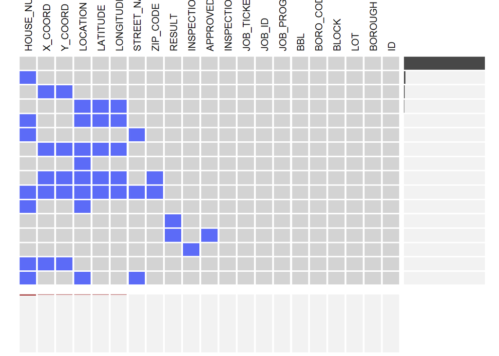

```r
data[ data == "NA" ] <- NA
visna(data, sort = "b")
```

Besides the completeness and uniqueness of data, the accuracy and validity are also examined. Since data collection process is unknown, a data validation check was conducted to ensure real-world right values are maintained. Mismatches between zip codes and borough are identified and eliminated. Records with incorrect dates are removed. For instance, several records with the year 2008 were seen while the data collection work had not started until 2009. These records were removed.

Overall, the data set from the New York City Government Open Database was maintained with a good accuracy and completeness.

### Data Cleaning Process:

#### For general analysis:

This dataset is from a government website. There are some anomalies in the data, mostly in the date column. The original dataset is ordered by ascending INSPECTION_DATE, which is a field in the dataset. We created a new column called ID using the row number, then we ordered the rows by INSPECTION_DATE. What we expected to see was ascending ID numbers. There were fewer than 20 anomalies in the data set. Comparing to the total 1.5 million number of rows in the data set, this number of anomalies is insignificant, so we just dropped them.

#### For interactivity:

There are many columns in the dataset and some of them are useless for the interactive part. Since we will read the data from Python, using FLASK to pass all the data to the HTML, and use Javascript and D3 to implement interactive plots, we need to make sure that the dataset is as small as possible to facilitate this whole process.

We took random samples from the original dataset and removed all the variables that are useless for the interactive part like `STREET_NAME` and `JOB_ID`. For the core variables like `longitude` and `latitude`, we dropped the rows if there is any NA in the data. For our convenience, we also removed INSPECTION_DATE column and replaced it by YEAR and MONTH that were extracted from INSPECTION_DATE. We also used `BORO_CODE` to represent the borough names in order to decrease the dataset size.

$~$

## Part 4. Exploratory data analysis

```r
data_edav <- read.csv("Rodent_Inspection_edav.csv")
```

Given the data available, our first objective was to evaluate the frequency of inspections and its distribution over time.

### a.Inspection_date

Given the data available, our first objective was to evaluate the frequency of inspections and its distribution over time. To make visualization simpler and more direct, we decided to convert time data in inspection_date to mm-yyyy format at first.

```r
data_edav$INSPECTION_DATE = format(as.Date(data_edav$INSPECTION_DATE),format='%Y-%m')
data_edav$INSPECTION_DATE = paste(data_edav$INSPECTION_DATE, "01", sep="-")
```

Then we started to explore the years to find out any overall trend.

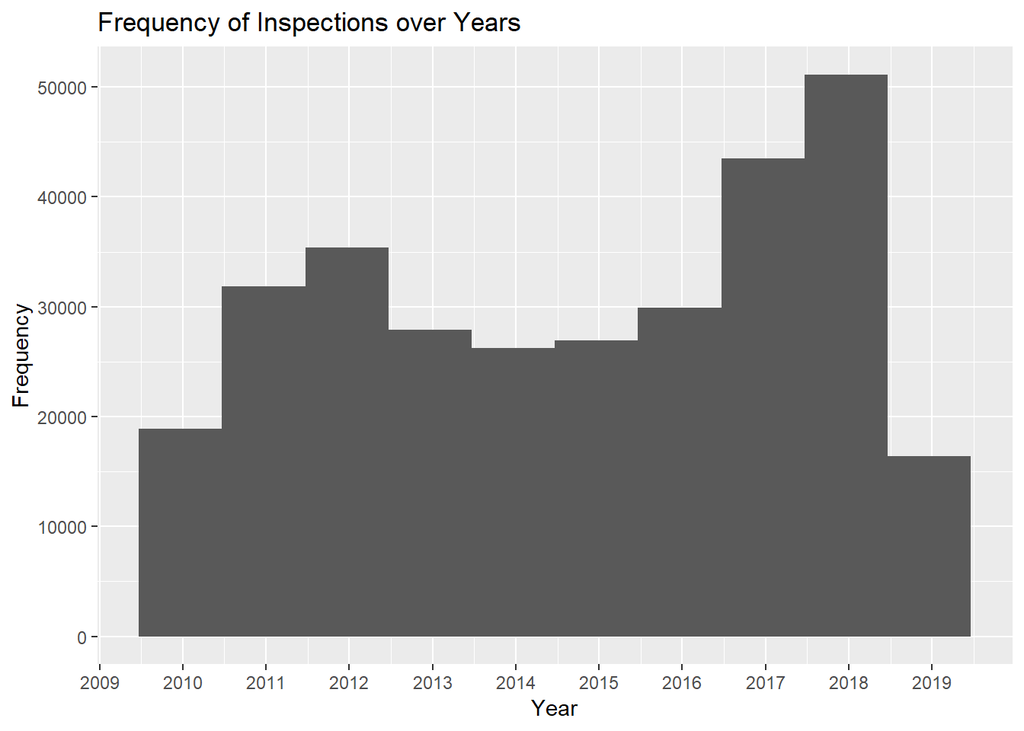

```r
ggplot(data_edav, aes(as.Date(INSPECTION_DATE))) +
  geom_histogram(binwidth = 365) +
  scale_x_date(date_breaks = "1 year", date_labels = "%Y") +
  ylab("Frequency") + xlab("Year") +
  ggtitle("Frequency of Inspections over Years")
```

Then we checked the monthly change of the data. From the figure above, we can find that in most years, rodent inspections happened less often from November to February when it was usually colder than in other months. This is possibly due to less activity of rodents in the winter.

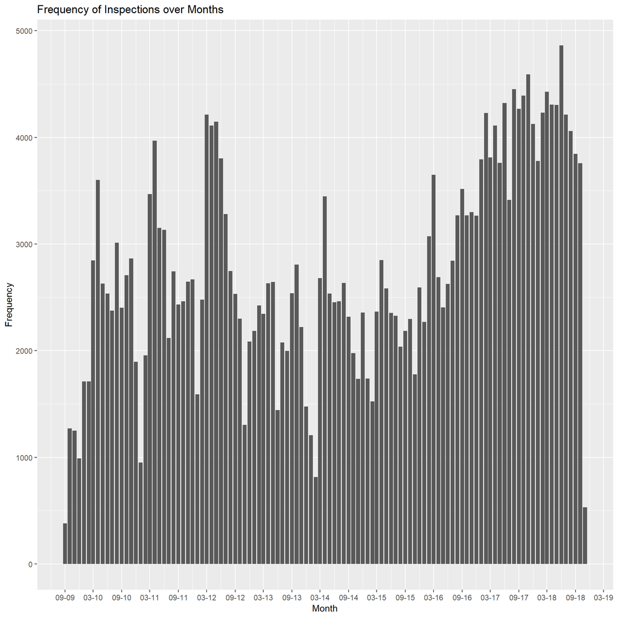

```r
ggplot(data_edav, aes(as.Date(INSPECTION_DATE))) +
  geom_bar(position = position_dodge(width = 1/3)) +
  scale_x_date(date_breaks = "6 months", date_labels = "%m-%y")+
  ylab("Frequency") + xlab("Month") +
  ggtitle("Frequency of Inspections over Months")
```

#### Association between date and borough:

To further explore how month influences the number of rodent inspections in different boroughs, we chose to use heat map to find the relationship between them:

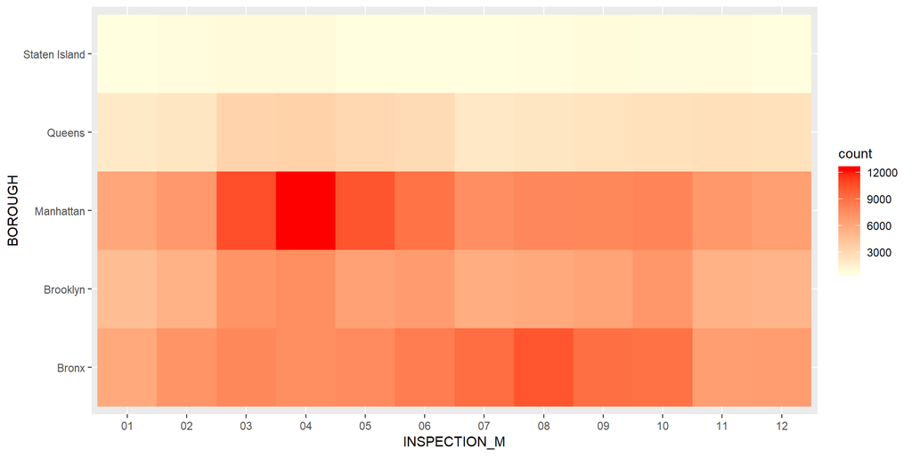

```r
data_edav$INSPECTION_M = format(as.Date(data_edav$INSPECTION_DATE),format='%m')
ggplot(data_edav,aes(x=INSPECTION_M, y = BOROUGH)) +
  geom_bin2d(binwidth = c(3, 1)) +
  scale_fill_gradient(low = 'lightyellow',high = 'red')
```

As shown above, we can draw the conclusion that high frequencies of rodent inspections happened in Manhattan and Bronx from March to October.

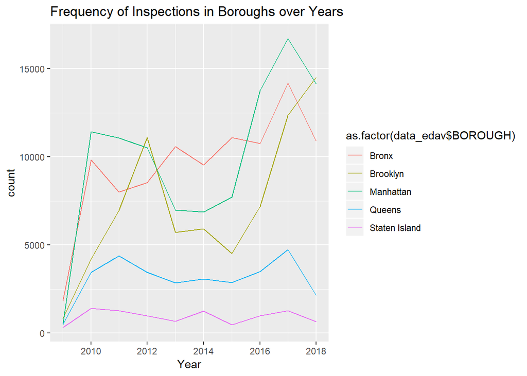

```r
data_edav$INSPECTION_Y = format(as.Date(data_edav$INSPECTION_DATE),format='%Y')

ggplot(data_edav, aes(x = as.numeric(data_edav$INSPECTION_Y),
                 group = data_edav$BOROUGH, colour = as.factor(data_edav$BOROUGH))) +
  geom_line(stat = 'count')  +
  xlab("Year") +
  ggtitle("Frequency of Inspections in Boroughs over Years")
```

According to the graphs above focusing on the time data, we can find that the main trend of rodent inspection frequency is increasing over years, and different boroughs have different trends of the number of rodent inspections. Furthermore, we can find that inspection frequency is associated with month, especially in Manhattan and Bronx.

### b.Inspection_type

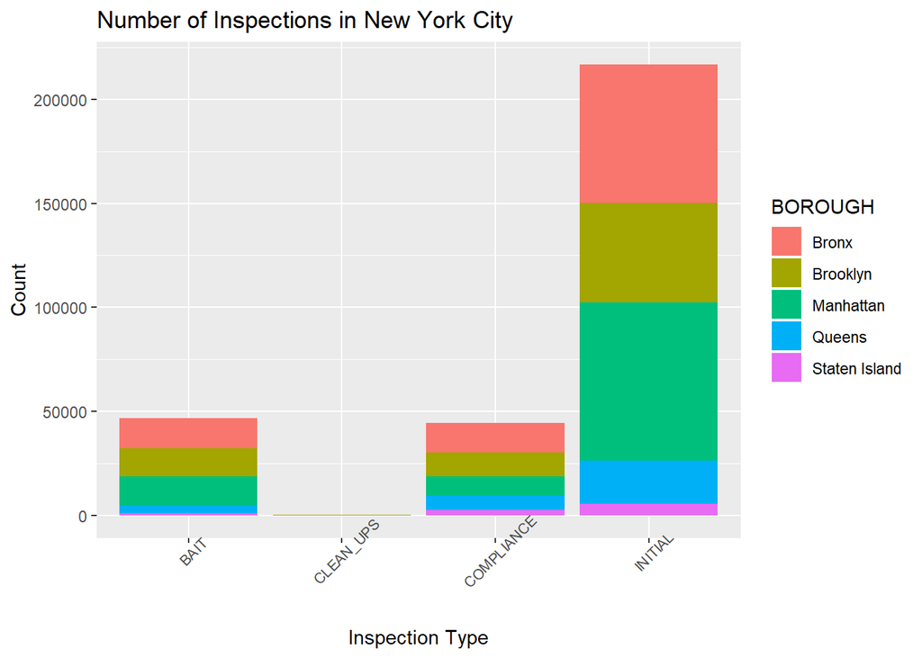

```r
# bar chart of total inspections
bar_chart <- ggplot(data_edav, aes(fill=BOROUGH, INSPECTION_TYPE)) + geom_bar() +
  theme(axis.text.x = element_text(size = 8, angle=45)) +
  ggtitle("Number of Inspections in New York City") + ylab("Count") + xlab("Inspection Type")
bar_chart
```

It seems that the counts of different types of inspections are different. From the first graph, it appears that the compliance number and the bait number is about the same. It makes sense according to the meaning of this inspection type, since after finding out there is a problem, the bait is needed to be set.

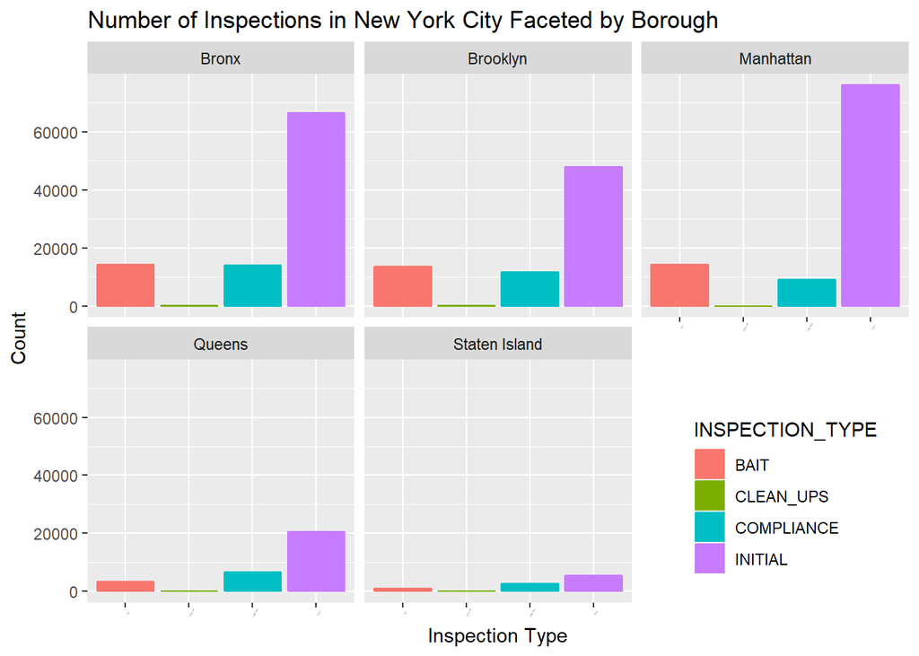

```r
# facet bar chart
facet_bar_chart <- ggplot(data_edav, aes(INSPECTION_TYPE, fill = INSPECTION_TYPE,
color = INSPECTION_TYPE)) + geom_bar() + facet_wrap(~BOROUGH) +
theme(axis.text.x = element_text(size = 0, angle=60), legend.position = c(0.85, 0.2)) +
ggtitle("Number of Inspections in New York City Faceted by Borough") + ylab("Count") +
  xlab("Inspection Type")
facet_bar_chart
```

However, from the second faceted graph, it seems that, for Manhattan, there are more “BAIT” than “COMPLIANCE”, while in Queens it is the opposite, which should be a problem. We need to figure out how many taxlots/properties have been inspected through the whole process (“INITIAL”, “COMPLIANCE”, and “BAIT”; the “CLEAN_UPS” is ignored as there are too few clean-ups. We guess that clean-ups are minor as there is no need for a fieldwork).

### c.Inspection result

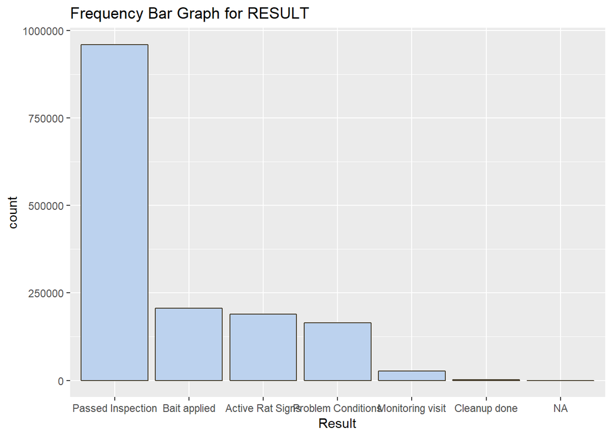

```r
ggplot(data,aes(x = fct_infreq(RESULT))) +
  geom_bar(fill = "lightsteelblue2", color = "#473e2c") +
  ggtitle("Frequency Bar Graph for RESULT") + xlab("Result")
```

The bar graph shows the distribution of `RESULT`. `Passed Inspection` appears to be significantly high frequency. Bait applied, Active Rat Sign, and Problem Conditions follow, and these three results have closed frequencies.

#### Association between Result and Borough:

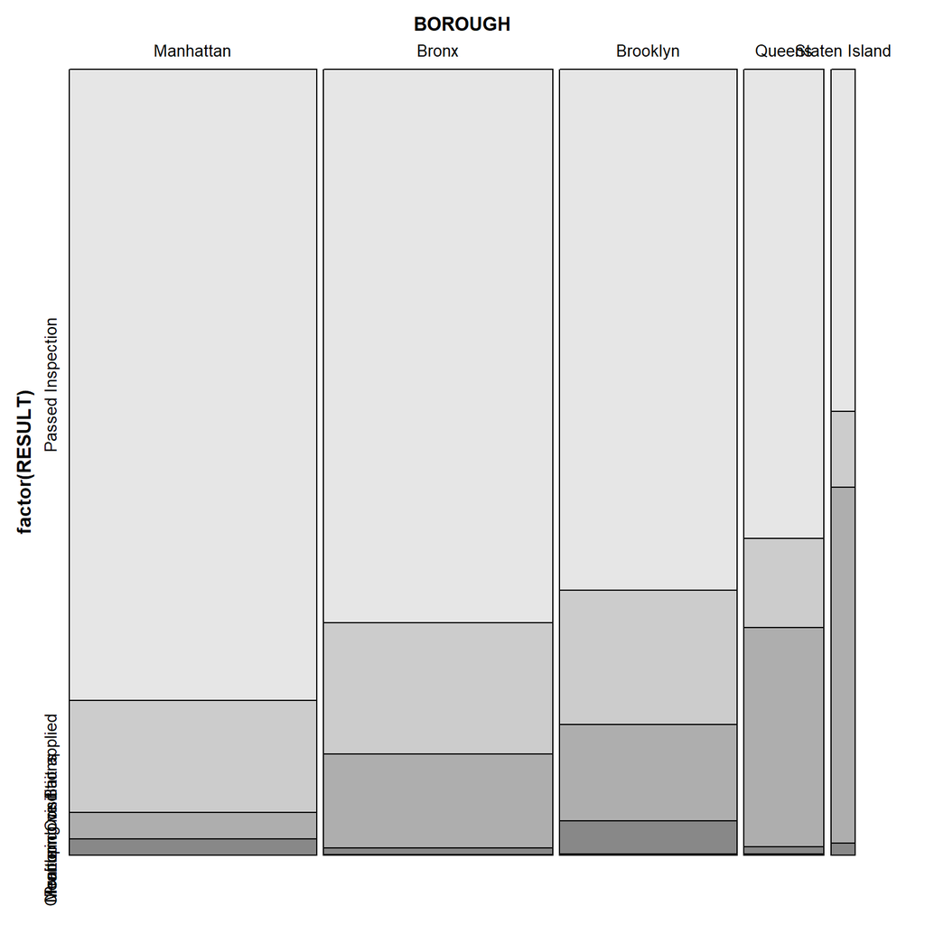

```r
library(vcd)
library(grid)

counts <- data_edav %>%
  group_by(RESULT, BOROUGH) %>%
  summarise(Freq = n()) %>%
  ungroup() %>%
  arrange(desc(Freq)) %>%
  complete(RESULT, BOROUGH)
counts$RESULT <- factor(counts$RESULT,
                                levels = c('Passed Inspection','Bait applied','Active Rat Sign','Problem Conditions','Monitoring visit','Cleanup done'))
counts$BOROUGH <- factor(counts$BOROUGH,
                         levels=c('Manhattan','Bronx','Brooklyn','Queens','Staten Island'))
mosaic(factor(RESULT)~BOROUGH, counts,
       direction = c('v','h'),gp_labels=(gpar(fontsize=10)))
```

The mosaic plot appears that there is some association between `RESULT` and `BOROUGH`. Manhattan appears to have the largest proportion of Passed Inspection, Bronx has the second largest, Brooklyn follows, while Staten Island has the smallest.

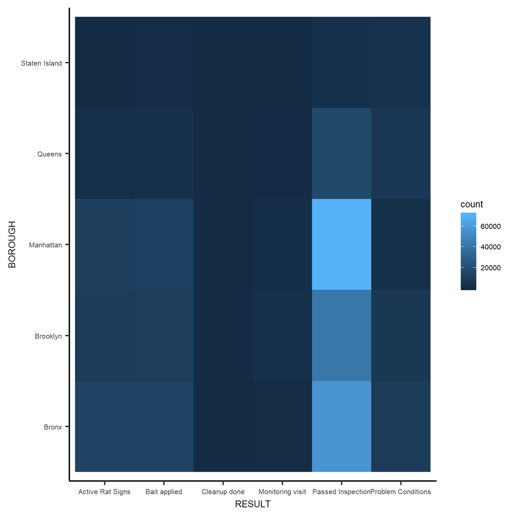

```r
library(hexbin)
library(dplyr)
ggplot(data_edav, aes(RESULT, BOROUGH)) +
  theme_classic(18) +
  geom_bin2d(bins = 15)+
  theme(text=element_text(size=10))
```

The heatmap shows the approximate count of each result in each borough. The count of Passed Inspection appears relatively very high in Manhattan, Bronx, and Brooklyn, which is consistent with the findings in the mosaic plot.

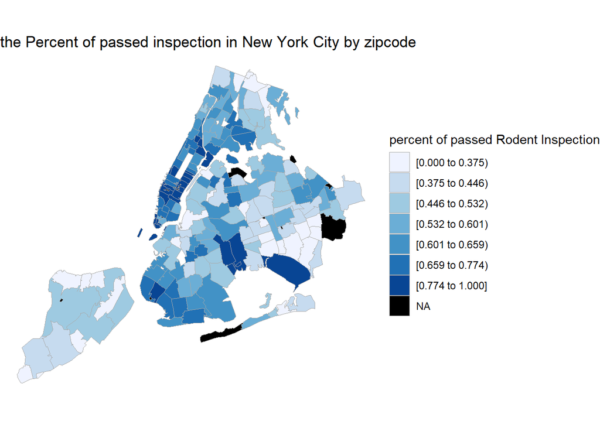

```r
library("choroplethr")
library(devtools)
install_github('arilamstein/choroplethrZip@v1.5.0')
library(choroplethrZip)
data_result<-data_edav%>%group_by(ZIP_CODE)%>%
  summarize(value=sum(RESULT=="Passed Inspection")/sum(ID!="NA"))
colnames(data_result)<-c("region","value")
data_result$region<-as.character(data_result$region)
nyc_fips = c(36005, 36047, 36061, 36081, 36085)
zip_choropleth(data_result,
               county_zoom = nyc_fips,
               title = "the Percent of passed inspection in New York City by zipcode",
               legend="percent of passed Rodent Inspection")
```

$~$

## Part 5. Executive summary

This project investigates the spatial distribution of rodent inspections in New York City by analyzing three aspects of inspection records: Inspection Date, Inspection Type, and Inspection Results. The first exploratory analysis addressed the frequency of inspection records in the last decade. The second analysis studied the distribution of inspection types. The last analysis focused on the results of inspections. This study based on the Rodent Inspection records from the NYC Open Data, which contained all records from year 2009 till 2018.

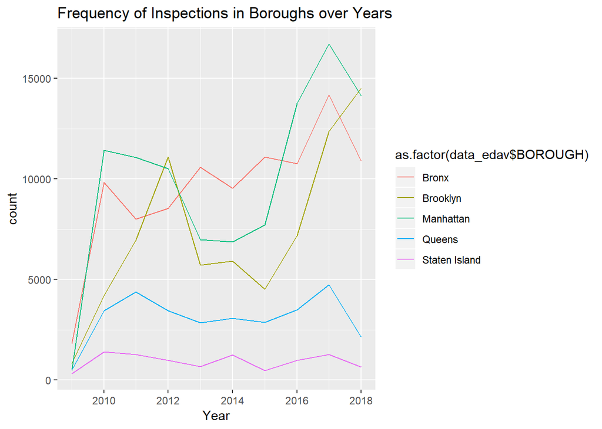

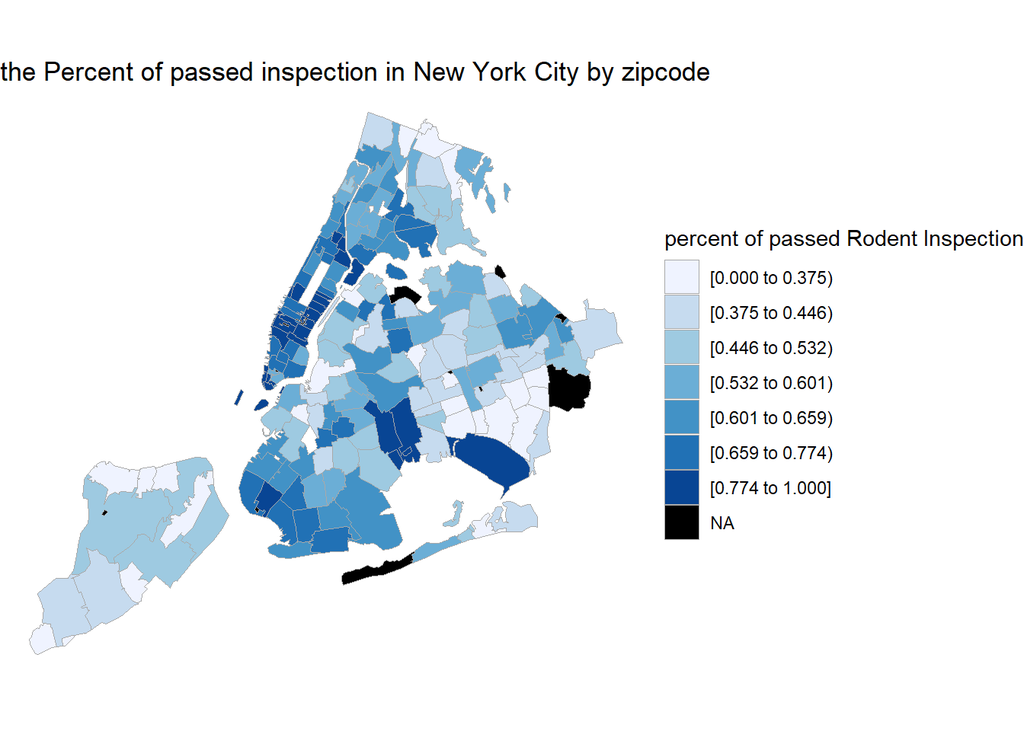

$~$

## Part 6. Interactive component

Link to the interactive component: http://104.196.205.14:8111/.

In this project, one of the most important parts is to show where the rodent inspections happened. To accomplish this, we implemented a webpage to visualize the spatial distribution of the rodent inspections on the NYC map.  
The visualization does not aim to give a great detail to users. Instead, it is showing a high-level trend to the audiences. Users can simply check which month(s), year(s), and borough(s) they want to visualize the data.

The dataset includes data points across all the boroughs of the New York City, so we chose a map of the whole NYC. Considering that the map is compacted, we decided not to use different colors to represent different inspection types. Instead, we put a summary section, which includes the number of cases of different inspection types. On the map, we only included the points to represent the places where the inspections took place.

We designed a form on the webpage, in which users can choose the months, years and boroughs. In the beginning, we only allowed users to choose a single month, single year and a single borough. However, later we realized that such limitation prevents users from discovering the spatial pattern of the data. Therefore, we revised the form and allowed multiple selections. Hopefully, using this tool, the users would have a better idea of the spatial distribution of the rodent inspections.

We also tried to let the users choose a specific zip code. However, as explained before, due to the size limitation of the map, selecting a zip would make the visualization harder to make sense. For example, there are about 55 zips in Manhattan, and each zip only covers a very small space on the map. Plotting points on the map is not clear at all. In the end, we decided not to move forward with this idea.

The value of this interactive part is to understand the trend. For business use, the user can only select a specific borough to know which part of this borough has a rodent problem and which part suffers less. This interactive part is more useful for the policymakers who would like to deal with the rodent problem in the NYC, since this visualization provides a wide picture of the whole problem. It is also good for the general public to explore the rodent problem in the NYC, for example, in which seasons rodent problems are more likely to occur or which year suffers the most. In a word, this interactive part is useful for a wide range of users. Different people can learn different things from this visualization.

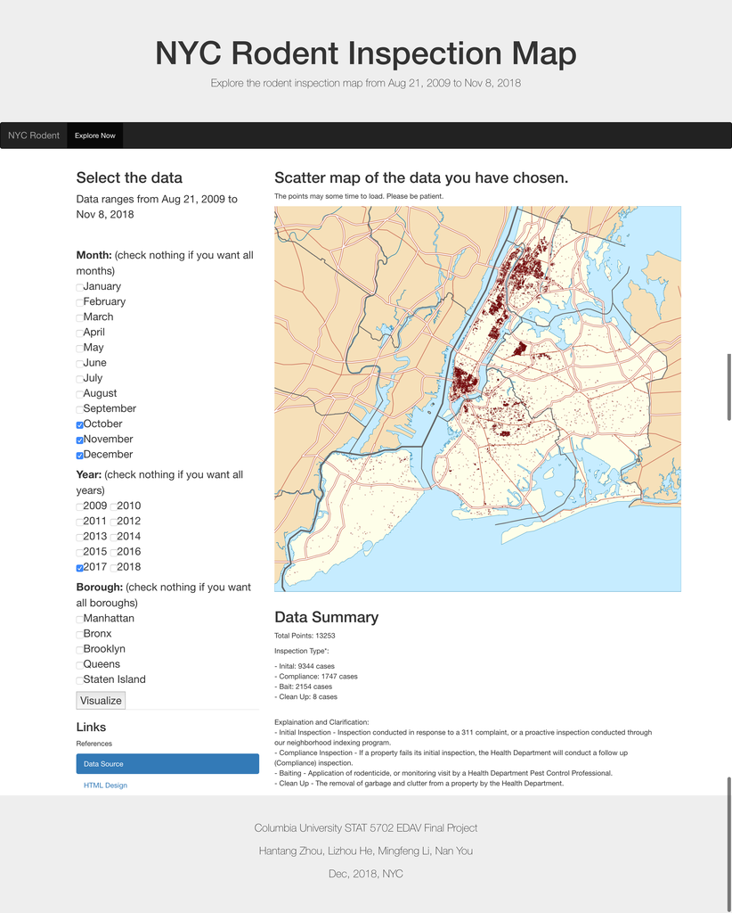

$~$

## Part 7. Conclusion

This project mainly focuses on the distribution of rodent inspection in both time and space dimensions. Because it helped to figure out the rodent distribution and give an intuitive knowledge of how time and space influenced the distribution.

Interactive part limitations and future directions:

1. Map Choice The map is found from Wikipedia. This map is too small for this visualization and it is lack of details. We can just see the main roads on the map. As a result, users cannot extract more information other than the approximate location of the inspections.
2. Map Zooming As explained before, the map is small. As a result, the plot gets very messy if there is a lot happens in the same neighborhood. The interactive part does not support the zoom in and zoom out functionality. Otherwise, the map would be much clearer.
3. Charts We did not include some corresponding charts for the map visualization. Typically a map visualization is enough. However, we could make it better if adding a bar chart showing the inspection types for each location.
4. Individual Data Points Details The interactive part focuses more on the big picture and ignores the individual data points. If we chose a better map and implemented the map zoom functionality, we could include more details about individual inspections, like the street name, room number, and more.

#### Future directions:

Due to the limited time, this project just focused on a few aspects with basic methods. So there are still a lot of work to do in the future to make this project more comprehensive. We could conduct more statistical analyses on the data, like linear regression and statistical inferences, to obtain more insights like how the data is distributed and how variables are correlated to each other. More external datasets can be combined with our interactive map, for example, locations and building information of real estate properties. In this way, users can see the rodent conditions around a property. This information could be beneficial for apartment/house renters or buyers on deciding where would be a good place to live. A rating system for rodent condition can also be added to mark the data points with different colors on the map. This would make the map clearer on which areas suffer more from rodents or less. In one word, more functionalities can be integrated with our project to obtain more valuable information.

#### Lessons learned:

In this project, we have tried a lot of methods to build the interactive map, such as drawing the heat map divided by zipcode with GeoJson. But none of us was familiar with this file format so that we had to give up after trying multiple times. Besides, due to the limitation of maximum data size that R can process, we had to choose a rather small data set to continue our work. The most important lesson is that when solving a real-world problem in limited time, it is better to be flexible with using alternative ways to achieve the goal.

$~$